# Ottawa Winter Temperature: freeze/thaw project — Run Length Analysis

## Overview

For an overview, these are nine examples of wintertime temperatures and their sample density plots that have been selected from the 56 years of data. The winter temperature variability is obvious but you can, also, start to see the differing freeze/thaw patterns for the different winter conditions. This is followed by a plot of mean monthly diurnal temperature for the 1970-2026 period, where the noise of the daily data has been removed. One observation seen from the graph is a reduced range of daily temperatures in December and January. And, as the spring approaches, the diurnal temperature range increases which has implications in producing changes in the freeze/thaw cycle.

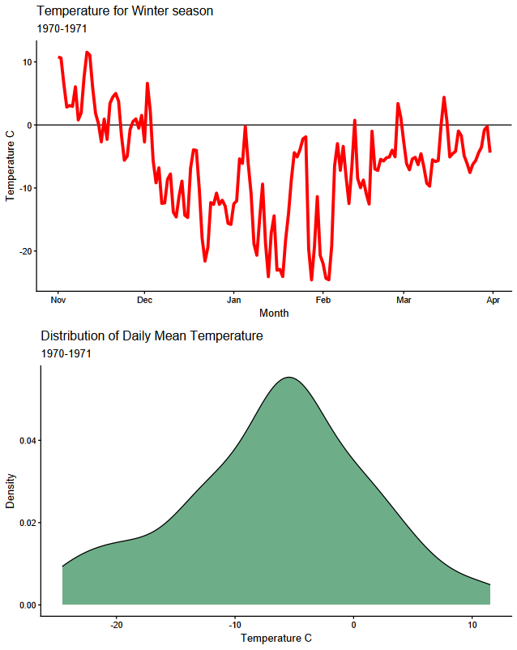

1970–71

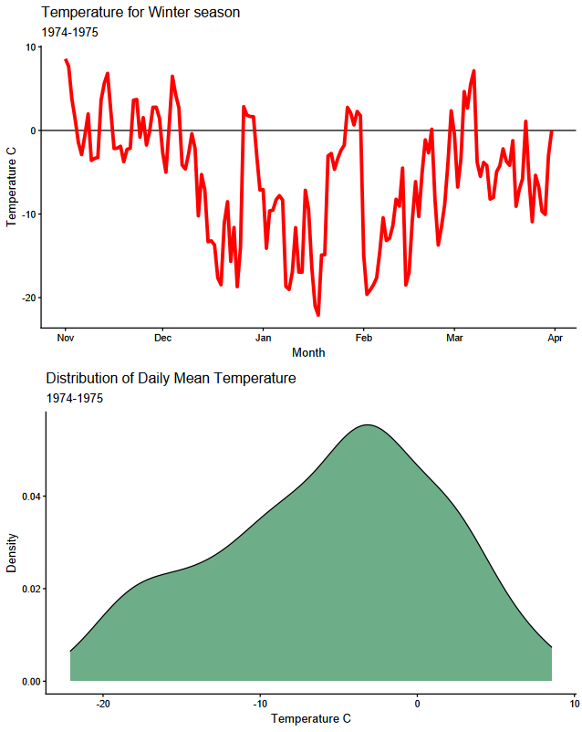

1974–75

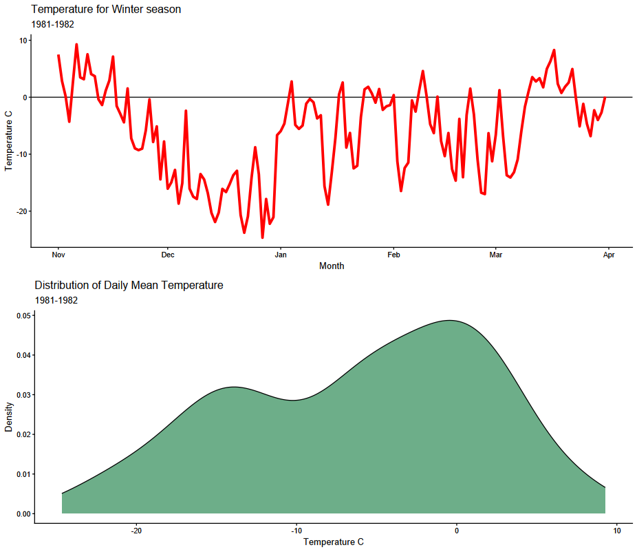

1981–82

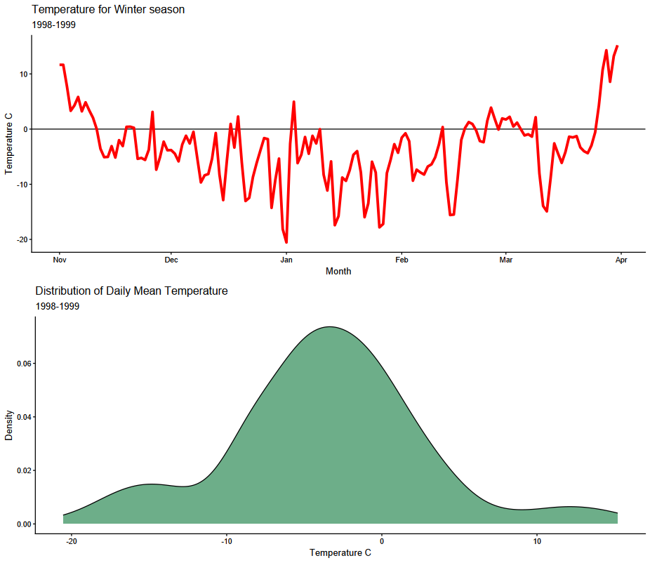

1998–99

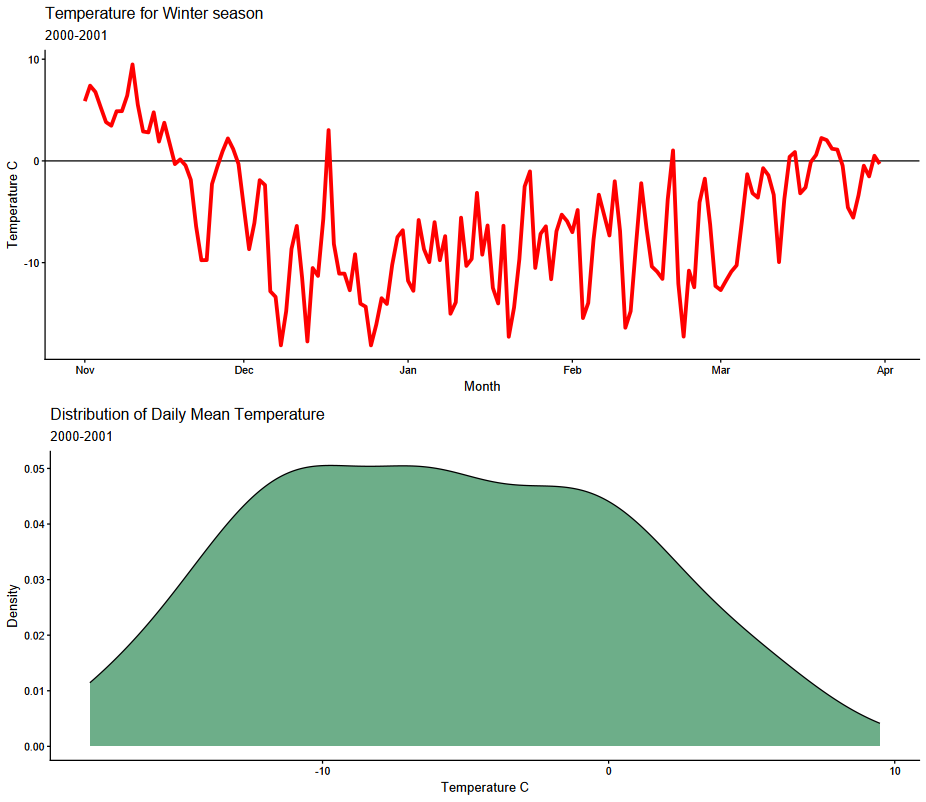

2000–01

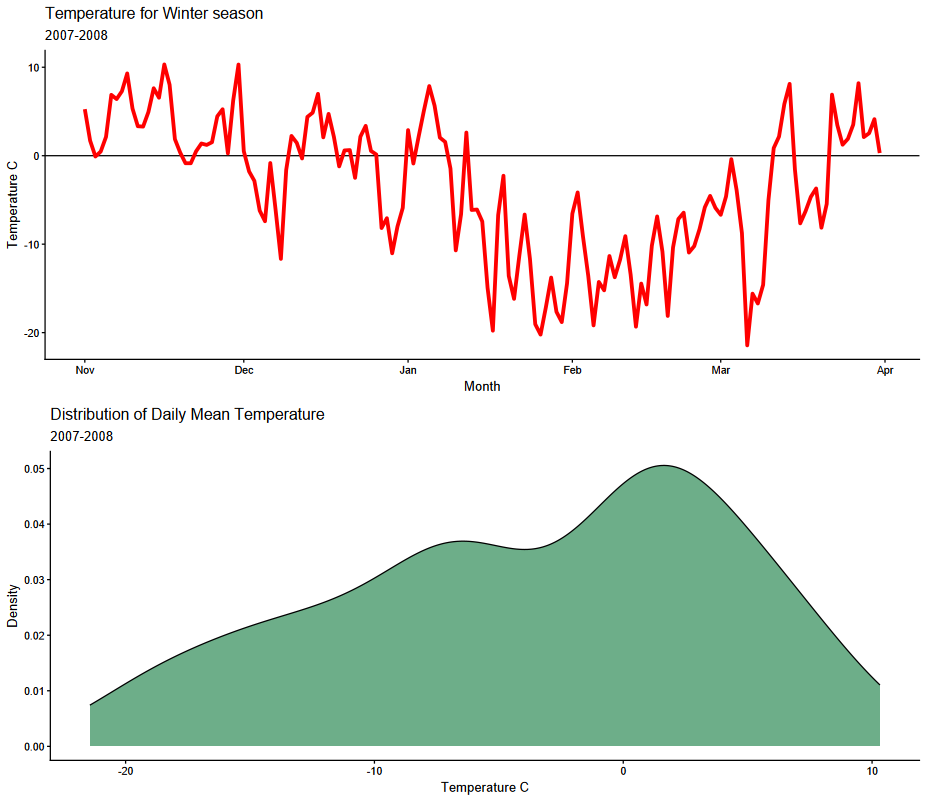

2007–08

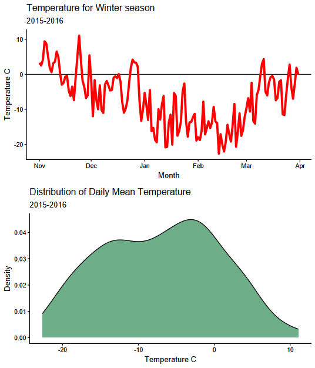

2015–16

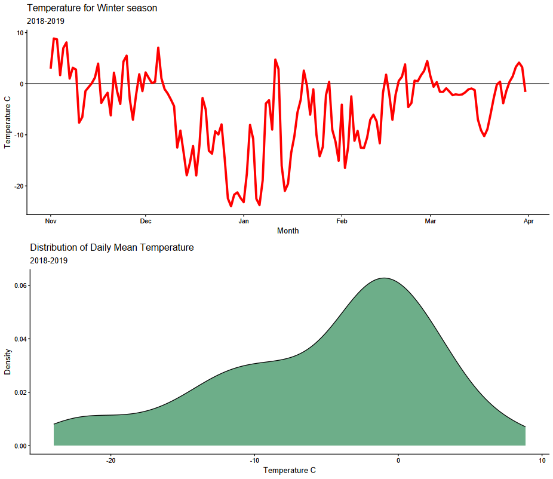

2018–19

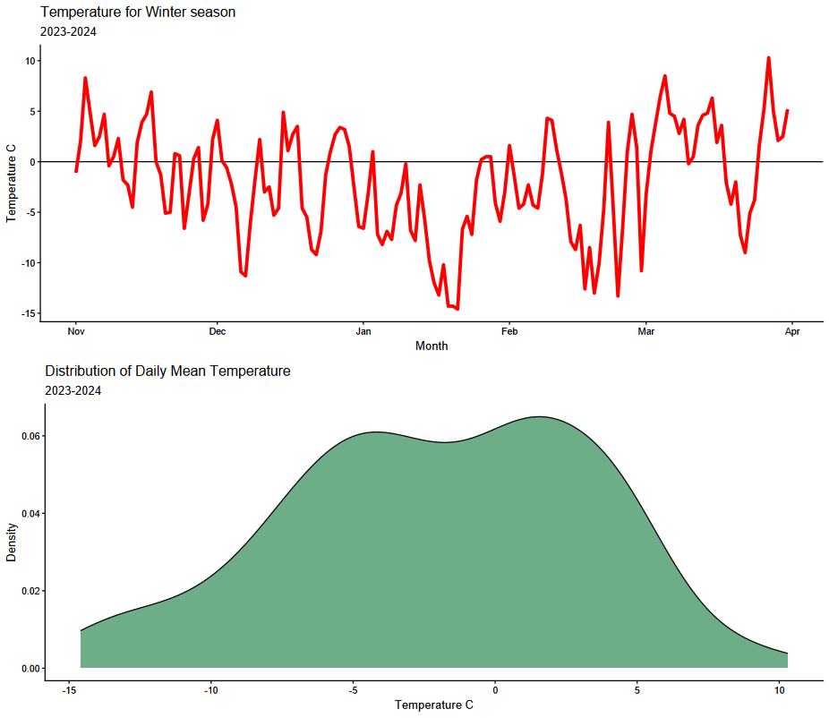

2023–24

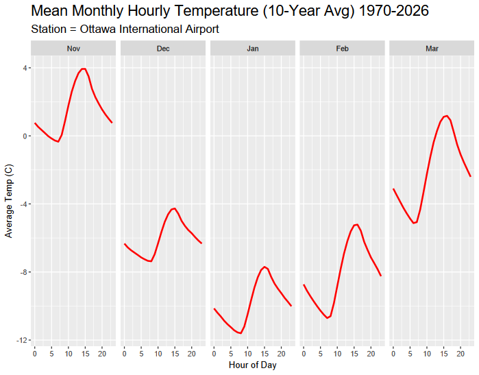

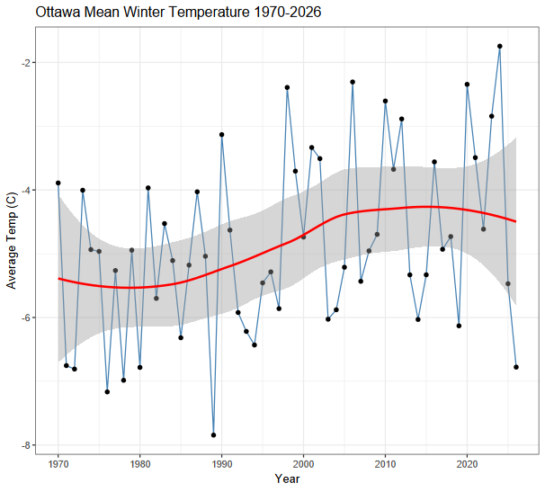

The following plot is a boxplots of yearly winter season temperatures, which present a more detailed picture of the wintertime temperatures pattern, over the entire 56 years. If you are not familiar with what boxplots are the following is a brief explanation.

A boxplot is a short cut method of displaying the distribution of all the temperature observations in the dataset. This is primarily done by grouping the data by their quartiles such that the value of the upper box includes 75% of all values; likewise the lower box value indicates only 25% of observed values. The values between the lower(25%) and upper(75%) box line is referred to as the interquartile range. A solid line within the box represents the median or middle value of the distribution. Boxplots may also have lines extending from the boxes (whiskers) indicating variability outside the upper and lower quartiles (tails of the distribution). One other graphical aspect you may see on a boxplot are individual points on either side of the whiskers. These individual points are negative or positive outliers (extreme observations) of data values depending on which side of the distribution that they occur. (see the example cartoon below)

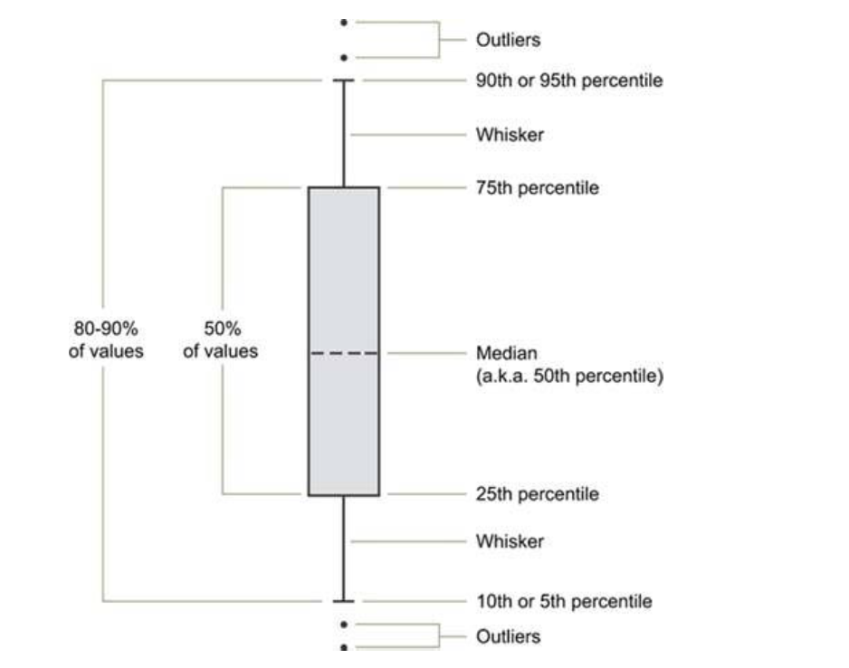

Each winter season has 3,624 hourly observations (3,648 in leap years). The vertical axis is scaled from a bit more than -40C to a bit less than 30C with 10C axis tics. The most striking aspect of this graph is the substantial variability in wintertime temperatures from year to year. The median value does appear to be increasing over the 56 years and even in the last decade there are noticeable warmer years alongside colder ones. The other striking thing for me is the outlier distributions. Some years have no extreme cold or warm temperature while others are characterized by a substantial number of outliers. There, also, appear many more occasions of extreme colder temperature in the early decades of the sample versus more positive (warmer) temperatures in the later decades. But the decade 2010-2019 may be an slight exception to that statement. There were a few colder winters with lots of temperature variability.intersperse among the general warming trend. Closer to the present, the winter of 2023-24 stands out as one of the warmest winters on record. Do you see other things that stand out to you?

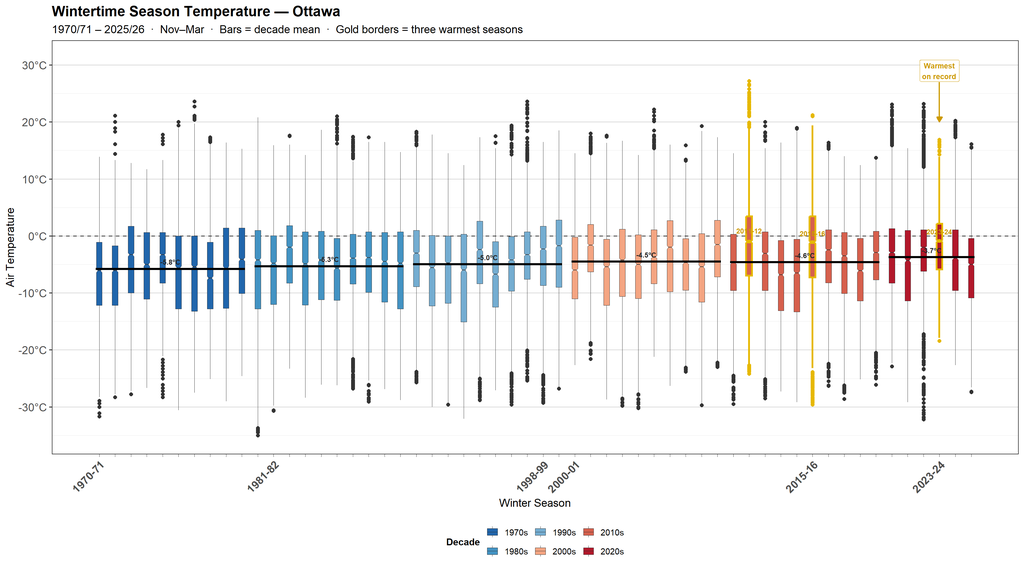

Hourly wintertime air temperature for Ottawa, Nov–Mar 1970/71–2025/26. Boxes are coloured by decade (cool blues → warm reds). Bold bars show the decade mean temperature. Gold borders highlight the three warmest seasons; the arrow marks the warmest season on record. Notice I have picked 6 years that are labeled on the graph which coincides with years on the first composit plot in the report. Scroll back to see the individual winter temperature pattern

```r
# ── Derived summaries (ot2 loaded in setup) ──────────────────────────────────

ot_box <- ot2 |>
  mutate(
    date   = as.Date(date),
    season = if_else(month %in% c(11L, 12L), year, year - 1L),
    decade = factor((season %/% 10) * 10)
  )

# Mean date per season (box x-position)
season_pos_b <- ot_box |>
  group_by(season) |>
  summarise(x_pos = as.Date(mean(as.numeric(date)), origin = "1970-01-01"),
            .groups = "drop")

# Seasonal mean temperatures
season_means_b <- ot_box |>
  group_by(season, decade) |>
  summarise(mean_temp = mean(temp.y, na.rm = TRUE), .groups = "drop") |>
  left_join(season_pos_b, by = "season")

# Decade means + segment endpoints (~half a season width in days)
half_box_b <- 76L

decade_means_b <- season_means_b |>
  group_by(decade) |>
  summarise(
    mean_temp = mean(mean_temp),
    x_start   = min(x_pos) - half_box_b,
    x_end     = max(x_pos) + half_box_b,
    x_mid     = as.Date(mean(as.numeric(x_pos)), origin = "1970-01-01"),
    .groups   = "drop"
  )

# ── Axis helpers ──────────────────────────────────────────────────────────────

labeled_seasons_b <- c(1970, 1981, 1998, 2000, 2015, 2023)
labeled_text_b    <- c("1970-71", "1981-82", "1998-99", "2000-01", "2015-16", "2023-24")

labeled_pos_b <- season_pos_b |>
  filter(season %in% labeled_seasons_b) |>
  arrange(season) |>
  pull(x_pos)

x_labeller_b <- function(x) {
  idx <- match(x, labeled_pos_b)
  ifelse(!is.na(idx), labeled_text_b[idx], "")
}

# ── Highlight layers ──────────────────────────────────────────────────────────

highlight_seasons_b <- c(2011, 2015, 2023)
highlight_labels_b  <- c("2011-12", "2015-16", "2023-24")

highlight_pos_b <- season_pos_b |>
  filter(season %in% highlight_seasons_b) |>
  arrange(season) |>
  left_join(season_means_b |> select(season, mean_temp), by = "season")

x_2023_b <- season_pos_b |> filter(season == 2023) |> pull(x_pos)

# ── Colour palette ────────────────────────────────────────────────────────────

decade_colors_b <- c(
  "1970" = "#2166ac", "1980" = "#4393c3", "1990" = "#74add1",
  "2000" = "#f4a582", "2010" = "#d6604d", "2020" = "#b2182b"
)

# ── Plot ──────────────────────────────────────────────────────────────────────

ggplot(ot_box, aes(date, temp.y, group = season, fill = decade)) +

  geom_hline(yintercept = 0, linetype = "dashed", linewidth = 0.55, colour = "grey30") +

  stat_boxplot(
    notch = TRUE, na.rm = TRUE,
    outlier.size = 0.25, outlier.alpha = 0.25, linewidth = 0.25
  ) +

  # Gold borders on the three warmest seasons
  stat_boxplot(
    data           = filter(ot_box, season %in% highlight_seasons_b),
    notch          = TRUE, na.rm = TRUE,
    fill           = NA, colour = "#E6B800",
    linewidth      = 1.1, outlier.colour = NA
  ) +

  # Decade mean bars
  geom_segment(
    data        = decade_means_b,
    aes(x = x_start, xend = x_end, y = mean_temp, yend = mean_temp),
    inherit.aes = FALSE, colour = "black", linewidth = 1.4
  ) +

  # Decade mean labels
  geom_text(
    data        = decade_means_b,
    aes(x = x_mid, y = mean_temp + 1.2,
        label = sprintf("%.1f\u00b0C", mean_temp)),
    inherit.aes = FALSE, size = 3.2, fontface = "bold", colour = "grey15"
  ) +

  # Warmest season name labels
  geom_text(
    data        = highlight_pos_b,
    aes(x = x_pos, y = mean_temp + 2.5,
        label = highlight_labels_b[match(season, highlight_seasons_b)]),
    inherit.aes = FALSE, size = 3.2, fontface = "bold", colour = "#CC9900"
  ) +

  # "Warmest on record" arrow and callout
  annotate("segment",
    x = x_2023_b, xend = x_2023_b, y = 27, yend = 20,
    colour = "#CC9900", linewidth = 0.8,
    arrow = arrow(length = unit(0.25, "cm"), type = "closed")
  ) +
  annotate("label",
    x = x_2023_b, y = 29,
    label = "Warmest\non record",
    size = 3.3, fontface = "bold", colour = "#CC9900",
    fill = "white", label.size = 0.4, label.padding = unit(0.3, "lines")
  ) +

  scale_fill_manual(
    values = decade_colors_b, name = "Decade",
    labels = c("1970s", "1980s", "1990s", "2000s", "2010s", "2020s")
  ) +
  scale_x_date(breaks = season_pos_b$x_pos, labels = x_labeller_b) +
  scale_y_continuous(
    breaks = seq(-40, 30, by = 10),
    labels = function(y) paste0(y, "\u00b0C"),
    limits = c(NA, 31)
  ) +
  labs(
    title    = "Wintertime Season Temperature \u2014 Ottawa",
    subtitle = "1970/71 \u2013 2025/26  \u00b7  Nov\u2013Mar  \u00b7  Bars = decade mean  \u00b7  Gold borders = three warmest seasons",
    x = "Winter Season", y = "Air Temperature"
  ) +
  theme_bw(base_size = 14) +
  theme(
    plot.title         = element_text(face = "bold", size = 18),
    plot.subttlie      = element_text(size = 14, colour = "black"),
    axis.text.x        = element_text(angle = 45, hjust = 1, size = 14, face = "bold"),
    axis.text.y        = element_text(size = 14),
    axis.title         = element_text(size = 14),
    axis.ticks.x       = element_line(linewidth = 0.35),
    panel.grid.major.x = element_blank(),
    panel.grid.minor.x = element_blank(),
    panel.grid.major.y = element_line(colour = "grey88"),
    legend.position    = "bottom",
    legend.title       = element_text(size = 12, face = "bold"),
    legend.text        = element_text(size = 11)
  )
```

# Representation of freeze-thaw cycles

The section investigate runs (sequence) of consecutive hourly temperature in the freeze thaw cycle that are greater than zero or equal to/less than zero for a winter season. The lengths (persistence) of runs, the number of times the temperature crosses through the zero value as well as the intensity(length x magnitude) of the runs are investigated.

## Run Length Distributions

### Positive Runs

Above-zero thaw events (above 0°C) show a consistent right-skewed distribution in every decade, with most runs lasting only a few hours.

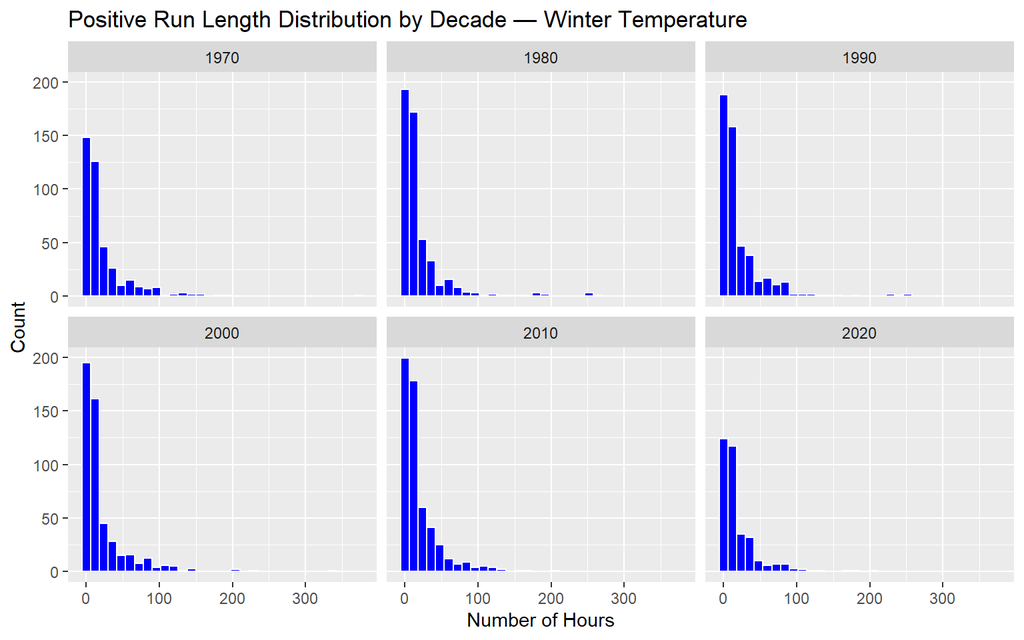

Figure 1: Distribution of positive run lengths by decade. Bin width = 12 hours.

```r
dt3 |>
  filter(sign == "pos") |>
  ggplot(aes(x = n)) +
  geom_histogram(binwidth = 12, fill = "blue", color = "white") +
  facet_wrap(~ decade, ncol = 3) +
  labs(
    title = "Positive Run Length Distribution by Decade — Winter Temperature",
    x = "Number of Hours", y = "Count"
  )
```

### Negative Runs (linear scale)

Cold spells (below 0°C) also follow a right-skewed distribution, but with a much wider range — some cold spells in the 1970s exceeded 1,000 hours (over 40 days).

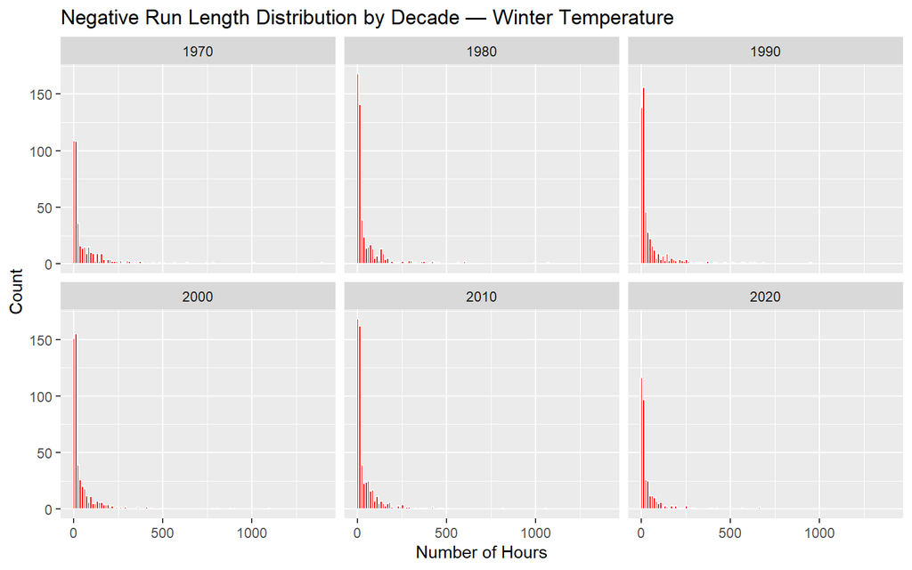

Figure 2: Distribution of negative run lengths by decade. Bin width = 12 hours.

```r
dt3 |>
  filter(sign == "neg") |>
  ggplot(aes(x = n)) +
  geom_histogram(binwidth = 12, fill = "red", color = "white") +
  facet_wrap(~ decade, ncol = 3) +
  labs(
    title = "Negative Run Length Distribution by Decade — Winter Temperature",
    x = "Number of Hours", y = "Count"
  )
```

### Negative Runs (log<sub>10</sub> scale)

Plotting on a log<sub>10</sub> x-axis reveals the full shape of the distribution across all run lengths.

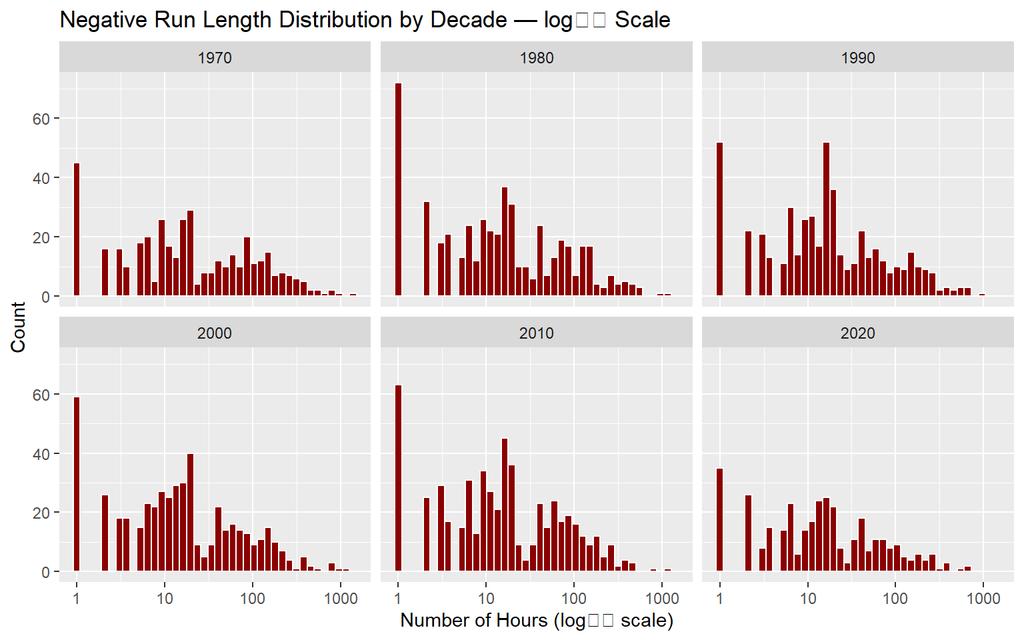

Figure 3: Distribution of negative run lengths by decade on a log10 x-axis.

```r
dt3 |>
  filter(sign == "neg") |>
  ggplot(aes(x = n)) +
  geom_histogram(bins = 40, fill = "darkred", color = "white") +
  scale_x_log10() +
  facet_wrap(~ decade, ncol = 3) +
  labs(
    title = "Negative Run Length Distribution by Decade — log\u2081\u2080 Scale",
    x = "Number of Hours (log\u2081\u2080 scale)", y = "Count"
  )
```

### Upper-Tail Negative Runs (> 96 hours)

Isolating only the prolonged cold spells (runs exceeding 4 days) shows the shape of the upper tail and its evolution across decades.

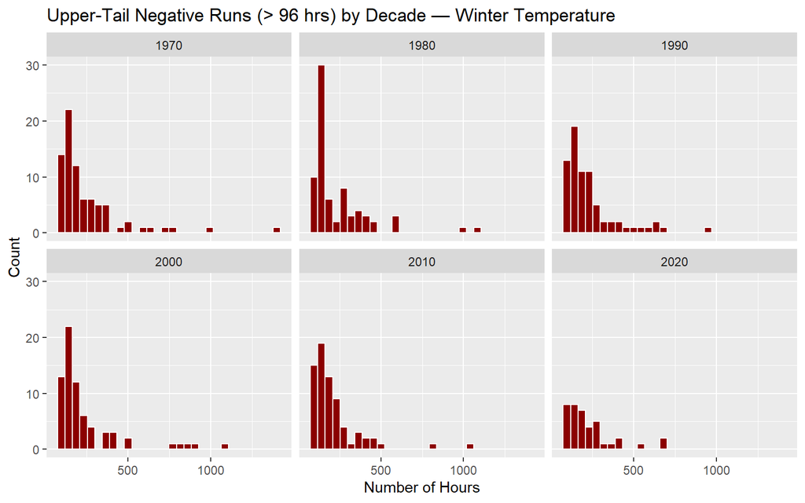

Figure 4: Negative runs exceeding 96 hours (4 days) by decade.

```r
dt3 |>
  filter(sign == "neg", n > 96) |>
  ggplot(aes(x = n)) +
  geom_histogram(bins = 30, fill = "darkred", color = "white") +
  facet_wrap(~ decade, ncol = 3) +
  labs(
    title = "Upper-Tail Negative Runs (> 96 hrs) by Decade — Winter Temperature",
    x = "Number of Hours", y = "Count"
  )
```

## Temporal Trends

### Mean and Median Negative Run Length

The mean negative run length has declined from approximately 66 hours in the 1970s to 43 hours in the 2020s, while the median has remained nearly flat at 14–16 hours throughout. This divergence indicates the decline is driven by a reduction in very long cold spells rather than a change in the typical short cold event.

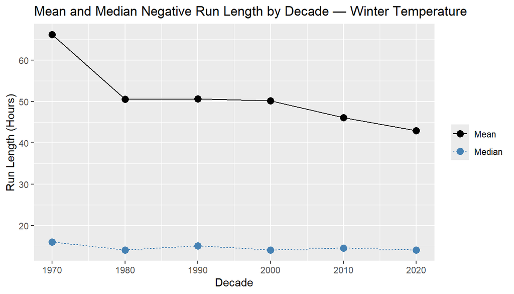

Figure 5: Mean and median negative run length per decade. The 2020s covers 2020–2026 only.

```r
run_stats_dec |>
  filter(sign == "neg") |>
  pivot_longer(cols = c(mean_len, median_len), names_to = "stat", values_to = "hours") |>
  mutate(stat = recode(stat, mean_len = "Mean", median_len = "Median")) |>
  ggplot(aes(x = decade, y = hours, color = stat, linetype = stat)) +
  geom_line() +
  geom_point(size = 3) +
  scale_x_continuous(breaks = seq(1970, 2020, 10)) +
  scale_color_manual(values = c("Mean" = "black", "Median" = "steelblue")) +
  labs(
    title = "Mean and Median Negative Run Length by Decade — Winter Temperature",
    x = "Decade", y = "Run Length (Hours)",
    color = NULL, linetype = NULL
  )
```

### Frequency of Long Cold Spells

The proportion of negative runs exceeding both the 4-day (96 hr) and 10-day (240 hr) thresholds has declined across the record, most notably from the 1970s onward.

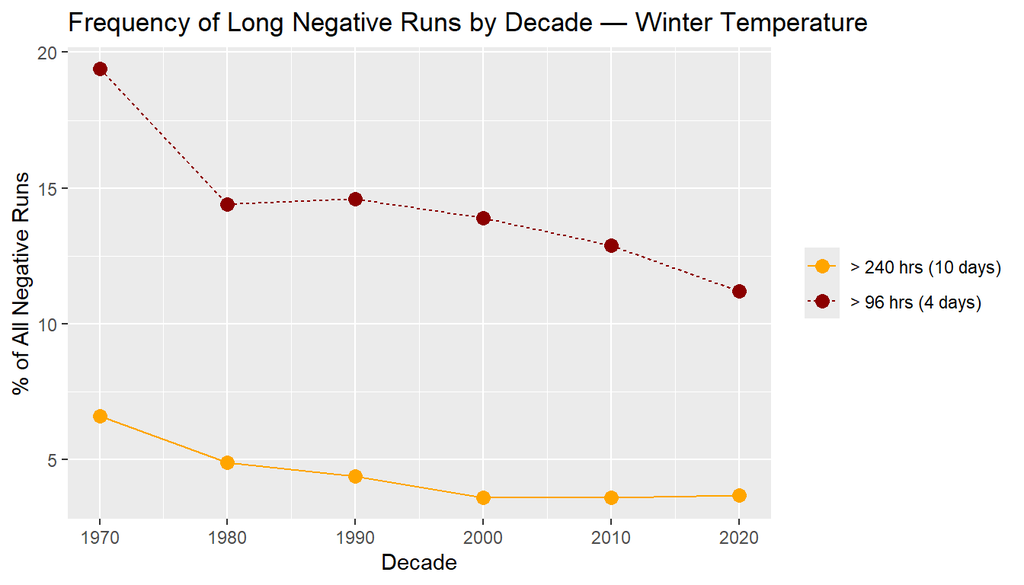

Figure 6: Percentage of negative runs exceeding 96 and 240 hour thresholds by decade.

```r
upper_tail |>
  pivot_longer(cols = c(gt96_pct, gt240_pct), names_to = "threshold", values_to = "pct") |>
  mutate(threshold = recode(threshold,
    gt96_pct  = "> 96 hrs (4 days)",
    gt240_pct = "> 240 hrs (10 days)"
  )) |>
  ggplot(aes(x = decade, y = pct, color = threshold, linetype = threshold)) +
  geom_line() +
  geom_point(size = 3) +
  scale_x_continuous(breaks = seq(1970, 2020, 10)) +
  scale_color_manual(values = c("> 96 hrs (4 days)" = "darkred", "> 240 hrs (10 days)" = "orange")) +
  labs(
    title = "Frequency of Long Negative Runs by Decade — Winter Temperature",
    x = "Decade", y = "% of All Negative Runs",
    color = NULL, linetype = NULL
  )
```

## Summary Statistics Table

Table 1 presents mean, median, and maximum run lengths for both positive and negative runs, along with the frequency of prolonged cold spells, for each decade.

```r
pos_stats <- run_stats_dec |>
  filter(sign == "pos") |>
  select(decade, pos_mean = mean_len, pos_median = median_len, pos_max = max_len)

neg_stats <- run_stats_dec |>
  filter(sign == "neg") |>
  select(decade, neg_mean = mean_len, neg_median = median_len, neg_max = max_len)

max_stats <- run_stats_dec |>
  select(decade, sign, max_len) |>
  pivot_wider(names_from = sign, values_from = max_len, names_prefix = "max_") |>
  rename(pos_max = max_pos, neg_max = max_neg)

summary_tbl2 <- pos_stats |>
  left_join(neg_stats, by = "decade") |>
  left_join(upper_tail |> select(decade, gt96_pct, gt240_pct), by = "decade") |>
  mutate(decade = paste0(decade, "s"))

summary_tbl2 |>
  gt() |>
  tab_header(
    title    = "Ottawa Winter Temperature — Run Length Statistics by Decade",
    subtitle = "Positive (above 0°C) and Negative (below 0°C) runs, Nov–Mar, 1970–2026"
  ) |>
  tab_spanner(label = "Positive Runs", columns = c(pos_mean, pos_median, pos_max)) |>
  tab_spanner(label = "Negative Runs", columns = c(neg_mean, neg_median, neg_max, gt96_pct, gt240_pct)) |>
  cols_label(
    decade     = "Decade",
    pos_mean   = "Mean (hrs)",
    pos_median = "Median (hrs)",
    pos_max    = "Max (hrs)",
    neg_mean   = "Mean (hrs)",
    neg_median = "Median (hrs)",
    neg_max    = "Max (hrs)",
    gt96_pct   = "% > 96 hrs",
    gt240_pct  = "% > 240 hrs"
  ) |>
  fmt_number(columns = c(pos_mean, neg_mean), decimals = 1) |>
  fmt_number(columns = c(pos_median, neg_median, pos_max, neg_max), decimals = 0) |>
  fmt_number(columns = c(gt96_pct, gt240_pct), decimals = 1) |>
  tab_style(
    style = cell_fill(color = "#f0f4ff"),
    locations = cells_column_spanners()
  ) |>
  tab_style(
    style = cell_text(weight = "bold"),
    locations = cells_column_labels()
  ) |>
  tab_style(
    style = cell_text(weight = "bold"),
    locations = cells_body(columns = decade)
  ) |>
  tab_style(
    style = cell_fill(color = "#fff0f0"),
    locations = cells_body(columns = neg_max)
  ) |>
  tab_footnote(
    footnote = "2020s covers 2020–2026 only (partial decade).",
    locations = cells_body(columns = decade, rows = decade == "2020s")
  ) |>
  tab_footnote(
    footnote = "Thresholds: > 96 hrs = 4 days; > 240 hrs = 10 days. Percentages are of all negative runs in that decade.",
    locations = cells_column_labels(columns = gt96_pct)
  ) |>
  tab_source_note("Source: Environment and Climate Change Canada hourly temperature data, Ottawa.")
```

Table 1: Run length statistics by decade for Ottawa winter temperature data (Nov–Mar).

Ottawa Winter Temperature — Run Length Statistics by Decade

Positive (above 0°C) and Negative (below 0°C) runs, Nov–Mar, 1970–2026

| Decade | Positive Runs Mean (hrs) | Positive Runs Median (hrs) | Positive Runs Max (hrs) | Negative Runs Mean (hrs) | Negative Runs Median (hrs) | Negative Runs Max (hrs) | Negative Runs % > 96 hrs<sup>1</sup> | Negative Runs % > 240 hrs |
| --- | --- | --- | --- | --- | --- | --- | --- | --- |
| 1970s | 23.0 | 11 | 378 | 66.2 | 16 | 1,398 | 19.4 | 6.6 |
| 1980s | 20.9 | 10 | 270 | 50.5 | 14 | 1,069 | 14.4 | 4.9 |
| 1990s | 21.8 | 9 | 257 | 50.7 | 15 | 944 | 14.6 | 4.4 |
| 2000s | 21.8 | 9 | 332 | 50.2 | 14 | 1,091 | 13.9 | 3.6 |
| 2010s | 19.9 | 10 | 209 | 46.1 | 14 | 1,061 | 12.9 | 3.6 |
| 2020s<sup>2</sup> | 19.8 | 10 | 207 | 42.9 | 14 | 666 | 11.2 | 3.7 |

<sup>1</sup> Thresholds: > 96 hrs = 4 days; > 240 hrs = 10 days. Percentages are of all negative runs in that decade.  
<sup>2</sup> 2020s covers 2020–2026 only (partial decade).  
Source: Environment and Climate Change Canada hourly temperature data, Ottawa.

## Statistical Tests

### Kruskal-Wallis: Run Lengths Across Decades

A Kruskal-Wallis rank-sum test was used to assess whether run length distributions differ significantly across decades. This non-parametric test is appropriate given the heavily right-skewed distributions.

```r
kw_pos <- kruskal.test(n ~ decade, data = dt3 |> filter(sign == "pos"))
kw_neg <- kruskal.test(n ~ decade, data = dt3 |> filter(sign == "neg"))

tibble(
  `Run type`     = c("Positive", "Negative"),
  `Chi-squared`  = c(round(kw_pos$statistic, 1), round(kw_neg$statistic, 1)),
  `df`           = c(kw_pos$parameter, kw_neg$parameter),
  `p-value`      = c(round(kw_pos$p.value, 3), round(kw_neg$p.value, 3)),
  `Interpretation` = c(
    "No significant difference across decades",
    "Not significant; 1970s shows largest departure"
  )
) |>
  gt() |>
  tab_style(
    style = cell_text(weight = "bold"),
    locations = cells_column_labels()
  ) |>
  fmt_number(columns = `p-value`, decimals = 3)
```

Table 2: Kruskal-Wallis test results for run lengths across decades.

| Run type | Chi-squared | df | p-value | Interpretation |
| --- | --- | --- | --- | --- |
| Positive | 1.4 | 5 | 0.920 | No significant difference across decades |
| Negative | 8.6 | 5 | 0.128 | Not significant; 1970s shows largest departure |

### Chi-Squared: Proportion of Long Cold Spells

A chi-squared test on the contingency table of long vs. short negative runs was used to test whether the prevalence of prolonged cold spells has changed across decades.

```r
cont_table <- upper_tail |>
  mutate(le96_count = total_runs - gt96_count) |>
  select(decade, gt96_count, le96_count) |>
  column_to_rownames("decade") |>
  as.matrix()

cont_table_240 <- upper_tail |>
  mutate(le240_count = total_runs - gt240_count) |>
  select(decade, gt240_count, le240_count) |>
  column_to_rownames("decade") |>
  as.matrix()

chisq_result <- chisq.test(cont_table)
chisq_240    <- chisq.test(cont_table_240)

tibble(
  `Threshold`    = c("> 96 hrs (4 days)", "> 240 hrs (10 days)"),
  `Chi-squared`  = c(round(chisq_result$statistic, 1), round(chisq_240$statistic, 1)),
  `df`           = c(chisq_result$parameter, chisq_240$parameter),
  `p-value`      = c(round(chisq_result$p.value, 3), round(chisq_240$p.value, 3)),
  `Interpretation` = c(
    "Significant; 1970s has notably more long runs",
    "Not significant; sample too sparse at this tail"
  )
) |>
  gt() |>
  tab_style(
    style = cell_text(weight = "bold"),
    locations = cells_column_labels()
  ) |>
  fmt_number(columns = `p-value`, decimals = 3)
```

Table 3: Chi-squared test results for the proportion of long negative runs across decades.

| Threshold | Chi-squared | df | p-value | Interpretation |
| --- | --- | --- | --- | --- |
| > 96 hrs (4 days) | 12.2 | 5 | 0.032 | Significant; 1970s has notably more long runs |
| > 240 hrs (10 days) | 7.0 | 5 | 0.219 | Not significant; sample too sparse at this tail |

The proportion of runs exceeding 96 hours differs significantly across decades (χ² = 12.2, df = 5, p = 0.03), driven primarily by the elevated frequency in the 1970s (standardised residual = +3.13). At the more extreme 240-hour threshold the result is not significant (p = 0.22), likely reflecting insufficient counts at that tail for reliable inference.

# Seasonal Warming Signal

```r
# Add correct winter season label: Nov/Dec -> season = that year; Jan/Feb/Mar -> season = year - 1
dt2_s <- dt2 |>
  mutate(
    date_time = as.POSIXct(time),
    mo        = month(date_time),
    season    = if_else(mo %in% c(11, 12), year, year - 1)
  )

# Run-length series with season label
dt3_s <- dt2_s |>
  count(series_id, sign) |>
  left_join(
    dt2_s |> group_by(series_id) |> summarise(season = first(season), .groups = "drop"),
    by = "series_id"
  )

# Seasonal mean temperature
yr_mean_s <- dt2_s |>
  group_by(season) |>
  summarise(mean_temp = mean(temp.y, na.rm = TRUE), .groups = "drop")

season_label <- function(x) paste0(x, "-", substr(x + 1, 3, 4))
```

## Above- and Below-Zero Hours per Season

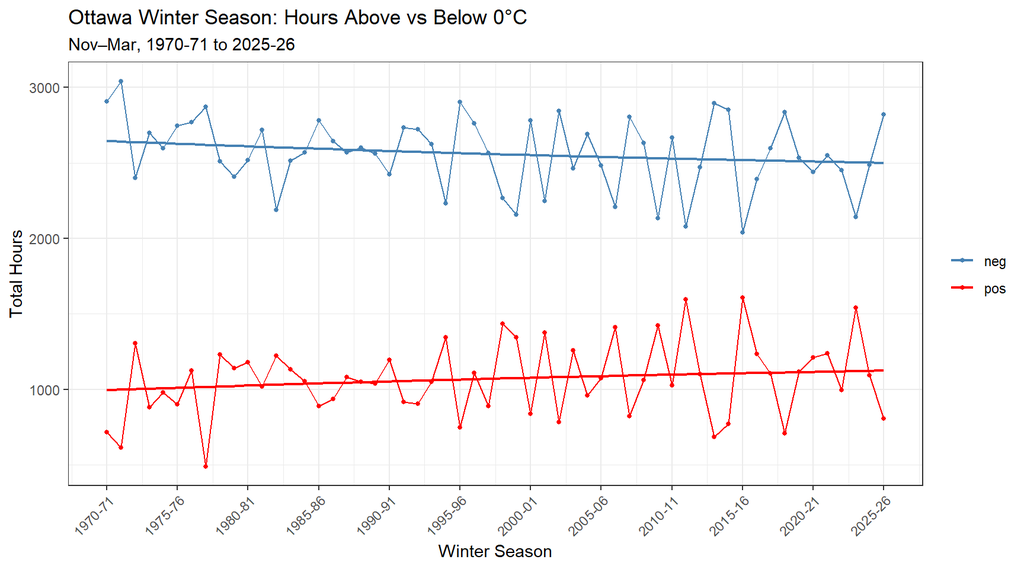

Figure 7: Total above- and below-zero hours per winter season, Nov–Mar 1970-71 to 2025-26. Lines are GAM trends.

```r
dt3_both_s <- dt3_s |>
  filter(sign %in% c("pos", "neg")) |>
  group_by(season, sign) |>
  summarise(n_total = sum(n), .groups = "drop")

dt3_both_s |>
  ggplot(aes(season, n_total, color = sign)) +
  geom_line() +
  geom_point(size = 1) +
  stat_smooth(method = "gam", se = FALSE, linewidth = 0.8) +
  scale_color_manual(values = c(neg = "steelblue", pos = "red")) +
  scale_x_continuous(breaks = seq(1970, 2025, by = 5), labels = season_label) +
  theme_bw() +
  theme(axis.text.x = element_text(angle = 45, hjust = 1)) +
  labs(
    title = "Ottawa Winter Season: Hours Above vs Below 0°C",
    subtitle = "Nov–Mar, 1970-71 to 2025-26",
    x = "Winter Season", y = "Total Hours", color = NULL
  )
```

## Ratio of Above- to Below-Zero Hours

Expressing the above-zero hours as a ratio of below-zero hours normalizes for any variation in season length and provides a single index of seasonal warmth. The GAM trend rises from approximately 0.39 in 1970-71 to 0.47 in 2025-26. Year-to-year variability is large, but the long-term direction is consistent.

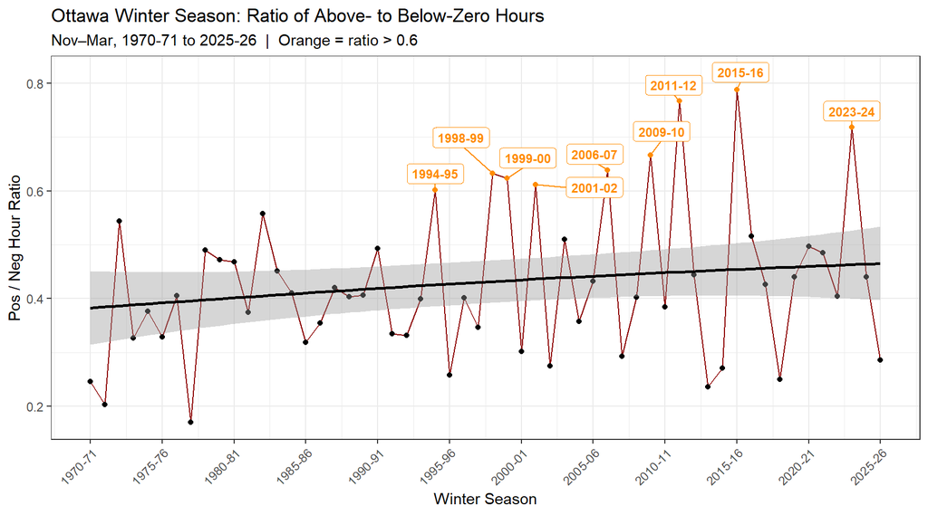

Figure 8: Ratio of above- to below-zero hours per winter season. Orange points and labels indicate seasons with ratio > 0.6. Line is a GAM trend.

```r
library(ggrepel)

dt3_ratio_s <- dt3_both_s |>
  pivot_wider(names_from = sign, values_from = n_total) |>
  mutate(
    ratio      = pos / neg,
    warm       = ratio > 0.6,
    season_lbl = season_label(season)
  )

ggplot(dt3_ratio_s, aes(season, ratio)) +
  geom_line(color = "darkred") +
  geom_point(aes(color = warm), size = 1.5) +
  geom_label_repel(
    data = filter(dt3_ratio_s, warm),
    aes(label = season_lbl),
    size = 3, color = "darkorange", fontface = "bold",
    nudge_y = 0.03, min.segment.length = 0
  ) +
  stat_smooth(method = "gam", color = "black", se = TRUE) +
  scale_color_manual(values = c("FALSE" = "black", "TRUE" = "darkorange"), guide = "none") +
  scale_x_continuous(breaks = seq(1970, 2025, by = 5), labels = season_label) +
  theme_bw() +
  theme(axis.text.x = element_text(angle = 45, hjust = 1)) +
  labs(
    title    = "Ottawa Winter Season: Ratio of Above- to Below-Zero Hours",
    subtitle = "Nov–Mar, 1970-71 to 2025-26  |  Orange = ratio > 0.6",
    x = "Winter Season", y = "Pos / Neg Hour Ratio"
  )
```

## Cross-Reference: Ratio vs Seasonal Mean Temperature

The pos/neg ratio and the seasonal mean temperature are tightly correlated (Pearson *r* = 0.81, 95% CI: 0.70–0.88, p < 0.0001), confirming they largely capture the same warming signal. The ratio does, however, provide additional information about the *structure* of warm periods: seasons such as 2015-16 and 2011-12 plot above the regression line, meaning their ratios were higher than their mean temperatures alone would predict, suggesting those seasons were characterized by fewer but longer sustained above-zero spells.

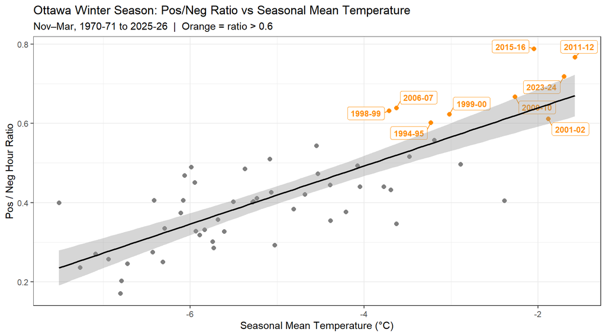

Figure 9: Pos/neg ratio vs seasonal mean temperature, 1970-71 to 2025-26. Orange labels show seasons with ratio > 0.6. Line is a linear regression fit.

```r
combined_s <- dt3_ratio_s |>
  left_join(yr_mean_s, by = "season")

ggplot(combined_s, aes(mean_temp, ratio)) +
  geom_point(aes(color = warm), size = 2) +
  geom_label_repel(
    data = filter(combined_s, warm),
    aes(label = season_lbl),
    size = 3, color = "darkorange", fontface = "bold",
    min.segment.length = 0
  ) +
  stat_smooth(method = "lm", color = "black", se = TRUE, linewidth = 0.8) +
  scale_color_manual(values = c("FALSE" = "grey50", "TRUE" = "darkorange"), guide = "none") +
  theme_bw() +
  labs(
    title    = "Ottawa Winter Season: Pos/Neg Ratio vs Seasonal Mean Temperature",
    subtitle = "Nov–Mar, 1970-71 to 2025-26  |  Orange = ratio > 0.6",
    x = "Seasonal Mean Temperature (°C)", y = "Pos / Neg Hour Ratio"
  )
```

## Run-Length Structure of the Warmest Seasons

The three seasons with the highest ratios — 2015-16, 2011-12, and 2023-24 — differ in the character of their warmth. Seasons 2015-16 and 2011-12 had fewer but longer sustained above-zero spells (maximum runs of 171 and 209 hours respectively), whereas 2023-24 had more numerous but shorter spells (75 runs, maximum 87 hours). This is consistent with those two seasons sitting above the regression line in the ratio vs mean temperature plot: their ratios reflect prolonged warm events, not simply a higher overall temperature.

```r
top_seasons <- c(2011, 2015, 2023)

warm_runs <- dt2_s |>
  filter(sign == "pos") |>
  group_by(season, series_id) |>
  summarise(run_hours = n(), .groups = "drop") |>
  group_by(season) |>
  summarise(
    n_runs       = n(),
    mean_run_hrs = round(mean(run_hours), 1),
    median_run   = median(run_hours),
    max_run_hrs  = max(run_hours),
    total_pos    = sum(run_hours),
    .groups = "drop"
  )

all_avg <- warm_runs |>
  summarise(
    season       = NA_real_,
    n_runs       = round(mean(n_runs), 1),
    mean_run_hrs = round(mean(mean_run_hrs), 1),
    median_run   = round(median(median_run), 1),
    max_run_hrs  = round(mean(max_run_hrs), 1),
    total_pos    = round(mean(total_pos), 0)
  )

warm_runs |>
  filter(season %in% top_seasons) |>
  mutate(season = season_label(season)) |>
  bind_rows(all_avg |> mutate(season = "All-season avg")) |>
  gt() |>
  tab_header(
    title    = "Positive Run Structure — Top 3 Warmest Seasons vs All-Season Average",
    subtitle = "Ottawa winter season (Nov–Mar)"
  ) |>
  cols_label(
    season       = "Season",
    n_runs       = "No. of Runs",
    mean_run_hrs = "Mean Run (hrs)",
    median_run   = "Median Run (hrs)",
    max_run_hrs  = "Max Run (hrs)",
    total_pos    = "Total Pos Hours"
  ) |>
  tab_style(
    style     = cell_text(weight = "bold"),
    locations = cells_column_labels()
  ) |>
  tab_style(
    style     = cell_fill(color = "#fff7e6"),
    locations = cells_body(rows = season %in% c("2011-12", "2015-16", "2023-24"))
  ) |>
  tab_style(
    style     = cell_fill(color = "#f0f4ff"),
    locations = cells_body(rows = season == "All-season avg")
  ) |>
  tab_footnote(
    footnote  = "No. of Runs is the actual count for each named season; the All-season avg row shows the mean across all 56 seasons.",
    locations = cells_column_labels(columns = n_runs)
  )
```

Table 4: Positive run-length structure for the three warmest seasons compared with the all-season average.

Positive Run Structure — Top 3 Warmest Seasons vs All-Season Average

Ottawa winter season (Nov–Mar)

| Season | No. of Runs<sup>1</sup> | Mean Run (hrs) | Median Run (hrs) | Max Run (hrs) | Total Pos Hours |
| --- | --- | --- | --- | --- | --- |
| 2011-12 | 61.0 | 25.7 | 11 | 209.0 | 1570 |
| 2015-16 | 54.0 | 29.8 | 14 | 171.0 | 1608 |
| 2023-24 | 75.0 | 19.9 | 12 | 87.0 | 1494 |
| All-season avg | 50.9 | 21.2 | 9 | 151.3 | 1067 |

<sup>1</sup> No. of Runs is the actual count for each named season; the All-season avg row shows the mean across all 56 seasons.

# Summary & Key Findings

**Note**

The 2020s decade covers only 2020–2026 and therefore represents approximately six winters. Comparisons with full decades should be made with caution.

If the reader is interested I provided some of the R code used in producing the graphics. Just click on where you see **CODE**

Disclosure: Posit AI Assistant assisted in the restructing of the project and helped correct and enhance some of the R code that produce the graphs.